# LGCPs - Spatial covariates

David Borchers and Finn Lindgren (scrawled over by Jonathan Lee)

Generated on 2022-06-10

Set things up

```r
library(INLA)
library(inlabru)
library(RColorBrewer)
library(ggplot2)
bru_options_set(inla.mode = "experimental")
```

## Introduction

We are going to fit spatial models to the gorilla data, using factor and continuous explanatory variables in this practical. We will fit one using the factor variable `vegetation`, the other using the continuous covariate `elevation`

(Jump to the bottom of the practical if you want to start gently with a 1D example!)

## Get the data

```r
data(gorillas, package = "inlabru")
```

This dataset is a list (see `help(gorillas)` for details. Extract the objects you need from the list, for convenience:

```r
nests <- gorillas$nests
mesh <- gorillas$mesh
boundary <- gorillas$boundary
gcov <- gorillas$gcov
```

!JL! gcov holds a bunch of attributes like aspect as well as the elevation and vegetation data. They’re all SpatialPixelsDataFrames, which i’m not familiar with, but seems to let you have a 2d grid, which can automatically yield the coordinates (as per its CRS) of each cell via the “coordinates” function. !JL!

## Factor covariates

Look at the vegetation type, nests and boundary:

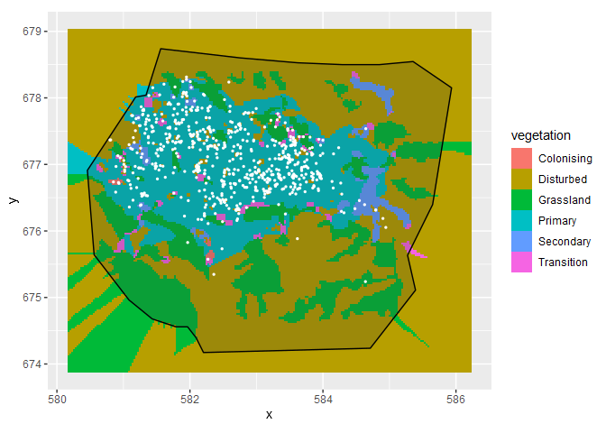

```r
ggplot() +
  gg(gcov$vegetation) +
  gg(boundary) +
  gg(nests, color = "white", cex = 0.5) +
  coord_equal()
```

Or, with the mesh:

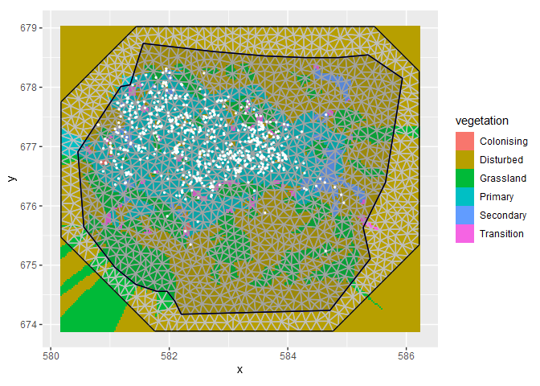

```r
ggplot() +
  gg(gcov$vegetation) +
  gg(mesh) +
  gg(boundary) +
  gg(nests, color = "white", cex = 0.5) +
  coord_equal()
```

#### A model with vegetation type only

It seems that vegetation type might be a good predictor because nearly all the nests fall in vegetation type `Primary`. So we construct a model with vegetation type as a fixed effect. To do this, we need to tell ‘lgcp’ how to find the vegetation type at any point in space, and we do this by creating model components with a fixed effect that we call `vegetation` (we could call it anything), as follows:

```r
comp1 <- coordinates ~ vegetation(gcov$vegetation, model = "factor_full") - 1
```

!JL!

Maybe this is obvious, but ‘coordinates’ can be another word, as long as its consistent.

!JL!

Notes: * We need to tell ‘lgcp’ that this is a factor fixed effect, which we do with `model="factor_full"`, giving one coefficient for each factor level. * We need to be careful about overparameterisation when using factors. Unlike regression models like ‘lm()’, ‘glm()’ or ‘gam()’, ‘lgcp()’, `inlabru` does not automatically remove the first level and absorb it into an intercept. Instead, we can either use `model="factor_full"` without an intercept, or `model="factor_contrast"`, which does remove the first level.

```r
comp1alt <- coordinates ~ vegetation(gcov$vegetation, model = "factor_contrast") + Intercept(1)
```

Fit the model as usual:

```r
fit1 <- lgcp(comp1, nests, samplers = boundary, domain = list(coordinates = mesh))
```

Predict the intensity, and plot the median intensity surface. (In older versions, predicting takes some time because we did not have vegetation values outside the mesh so ‘inlabru’ needed to predict these first. Since v2.0.0, the vegetation has been pre-extended.)

The `predict` function of `inlabru` takes into its `data` argument a `SpatialPointsDataFrame`, a `SpatialPixelsDataFrame` or a `data.frame`. We can use the `inlabru` function `pixels` to generate a `SpatialPixelsDataFrame` only within the boundary, using its `mask` argument, as shown below.

!JL!

I find the section below confusing, since it seems to get the vegetation data from the mesh. I can see how this could be used to create the SpatialPixelsDataFrame, but the mesh doesn’t seem to have the data in it.

!JL!

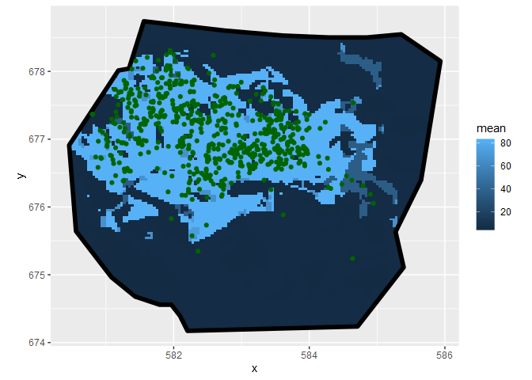

```r
df <- pixels(mesh, mask = boundary)
int1 <- predict(fit1, data = df, ~ exp(vegetation))
ggplot() +
  gg(int1) +
  gg(boundary, alpha = 0, lwd = 2) +
  gg(nests, color = "DarkGreen") +
  coord_equal()
```

Not surprisingly, given that most nests are in `Primary` vegetation, the high density is in this vegetation. But there are substantial patches of predicted high density that have no nests, and some areas of predicted low density that have nests. What about the estimated abundance (there are really 647 nests there):

```r
ips <- ipoints(boundary, mesh)
Lambda1 <- predict(fit1, ips, ~ sum(weight * exp(vegetation)))
Lambda1
```

```
#>       mean       sd   q0.025   median   q0.975     smin    smax         cv
#> 1 592.7668 21.48521 558.7389 591.7914 633.8081 543.8051 645.842 0.03624563
#>        var
#> 1 461.6141
```

#### A model with vegetation type and a SPDE type smoother

Lets try to `explain` the pattern in nest distribution that is not captured by the vegetation covariate, using an SPDE:

```r
pcmatern <- inla.spde2.pcmatern(mesh,
  prior.sigma = c(0.1, 0.01),
  prior.range = c(5, 0.01)
)
comp2 <- coordinates ~
-1 +
  vegetation(gcov$vegetation, model = "factor_full") +
  mySmooth(coordinates, model = pcmatern)
```

```r
fit2 <- lgcp(comp2, nests, samplers = boundary, domain = list(coordinates = mesh))
```

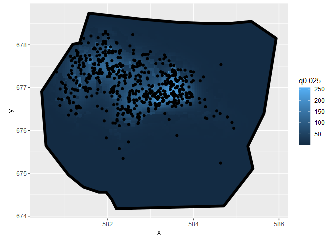

```r
df <- pixels(mesh, mask = boundary)
int2 <- predict(fit2, df, ~ exp(mySmooth + vegetation), n.samples = 1000)
ggplot() +
  gg(int2, aes(fill = q0.025)) +
  gg(boundary, alpha = 0, lwd = 2) +
  gg(nests) +
  coord_equal()
```

… and the expected integrated intensity (mean of abundance)

```r
Lambda2 <- predict(
  fit2,
  ipoints(boundary, mesh),
  ~ sum(weight * exp(mySmooth + vegetation))
)
Lambda2
```

```
#>       mean       sd   q0.025   median  q0.975     smin     smax         cv
#> 1 681.4522 26.40789 636.4063 683.1199 730.783 631.0473 745.0153 0.03875238
#>        var
#> 1 697.3767
```

Look at the contributions to the linear predictor from the SPDE and from vegetation:

```r
lp2 <- predict(fit2, df, ~ list(
  smooth_veg = mySmooth + vegetation,
  smooth = mySmooth,
  veg = vegetation
))
```

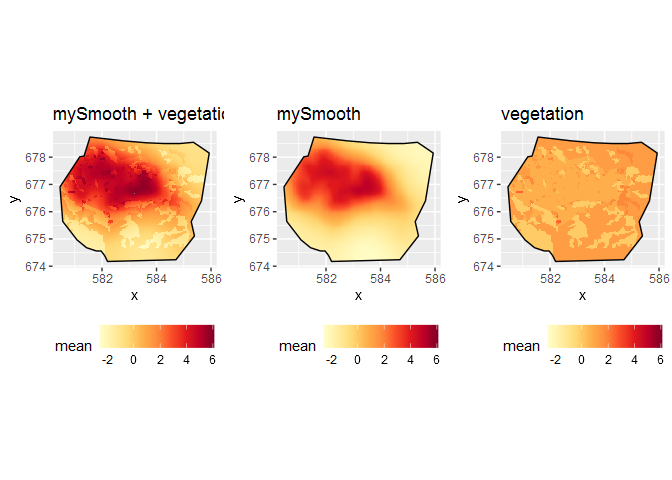

```r
lprange <- range(lp2$smooth_veg$median, lp2$smooth$median, lp2$veg$median)
csc <- scale_fill_gradientn(colours = brewer.pal(9, "YlOrRd"), limits = lprange)
plot.lp2 <- ggplot() +
  gg(lp2$smooth_veg) +
  csc +
  theme(legend.position = "bottom") +
  gg(boundary, alpha = 0) +
  ggtitle("mySmooth + vegetation") +
  coord_equal()
plot.lp2.spde <- ggplot() +
  gg(lp2$smooth) +
  csc +
  theme(legend.position = "bottom") +
  gg(boundary, alpha = 0) +
  ggtitle("mySmooth") +
  coord_equal()
plot.lp2.veg <- ggplot() +
  gg(lp2$veg) +
  csc +
  theme(legend.position = "bottom") +
  gg(boundary, alpha = 0) +
  ggtitle("vegetation") +
  coord_equal()
multiplot(plot.lp2, plot.lp2.spde, plot.lp2.veg, cols = 3)
```

#### A model with SPDE only

Do we need vegetation at all? Fit a model with only an SPDE + Intercept, and choose between models on the basis of DIC, using ‘deltaIC()’.

```r
comp3 <- coordinates ~ mySmooth(coordinates, model = pcmatern) + Intercept(1)
fit3 <- lgcp(comp3,
  data = nests,
  samplers = boundary,
  domain = list(coordinates = mesh)
)
```

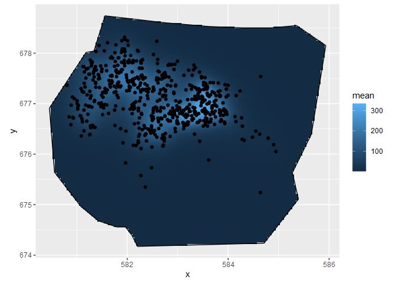

```r
int3 <- predict(fit3, df, ~ exp(mySmooth + Intercept))
ggplot() +
  gg(int3) +
  gg(boundary, alpha = 0) +
  gg(nests) +
  coord_equal()
```

```r
Lambda3 <- predict(
  fit3,
  ipoints(boundary, mesh),
  ~ sum(weight * exp(mySmooth + Intercept))
)
Lambda3
```

```
#>       mean       sd   q0.025   median   q0.975     smin     smax         cv
#> 1 670.6127 28.97924 617.6308 668.4806 717.6462 609.5766 739.8442 0.04321308
#>        var
#> 1 839.7961
```

```r
knitr::kable(cbind(
  deltaIC(fit1, fit2, fit3, criterion = c("DIC")),
  deltaIC(fit1, fit2, fit3, criterion = c("WAIC"))))
```

| Model | DIC | Delta.DIC | Model | WAIC | Delta.WAIC |
| --- | --- | --- | --- | --- | --- |
| fit1 | -692.9239 | 0.000 | fit1 | 1373.068 | 0.0000 |
| fit3 | 509.9149 | 1202.839 | fit3 | 1585.011 | 211.9431 |
| fit2 | 598.2010 | 1291.125 | fit2 | 1637.522 | 264.4536 |

NOTE: the behaviour of DIC and WAIC is currently a bit unclear, in particular for experimental mode, and is being investigated.

Classic mode:

| Model | DIC | Delta.DIC | Model | WAIC | Delta.WAIC |
| --- | --- | --- | --- | --- | --- |
| fit2 | 2224.131 | 0.00000 | fit1 | 2672.234 | 0.0000 |
| fit3 | 2274.306 | 50.17504 | fit3 | 2949.498 | 277.2636 |
| fit1 | 3124.784 | 900.65339 | fit2 | 3040.140 | 367.9051 |

Experimental mode:

| Model | DIC | Delta.DIC | Model | WAIC | Delta.WAIC |
| --- | --- | --- | --- | --- | --- |
| fit1 | -563.3583 | 0.000 | fit1 | 1373.241 | 0.0000 |
| fit3 | 509.4010 | 1072.759 | fit3 | 1584.543 | 211.3021 |
| fit2 | 597.6459 | 1161.004 | fit2 | 1636.864 | 263.6225 |

#### CV and SPDE parameters for Model 2

We are going with Model `fit2`. Lets look at the spatial distribution of the coefficient of variation

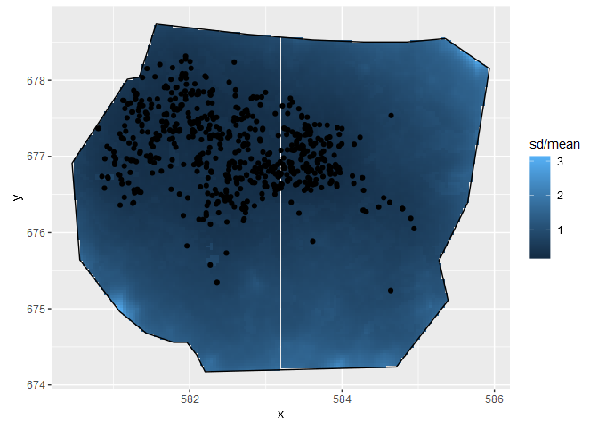

```r
ggplot() +
  gg(int2, aes(fill = sd / mean)) +
  gg(boundary, alpha = 0) +
  gg(nests) +
  coord_fixed()
```

Plot the vegetation “fixed effect” posteriors. First get their names - from `$marginals.random$vegetation` of the fitted object, which contains the fixed effect marginal distribution data

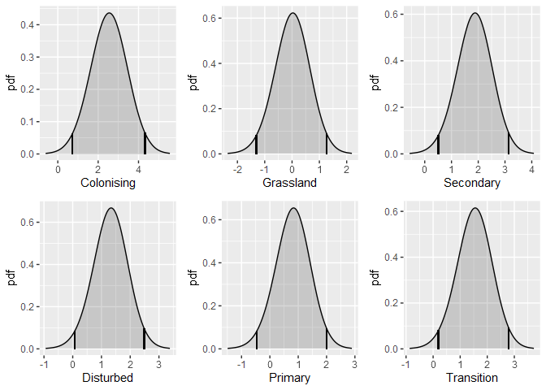

```r
flist <- vector("list", NROW(fit2$summary.random$vegetation))
for (i in seq_along(flist)) flist[[i]] <- plot(fit2, "vegetation", index = i)
multiplot(plotlist = flist, cols = 3)
```

Use `spde.posterior( )` to obtain and then plot the SPDE parameter posteriors and the Matern correlation and covariance functions for this model.

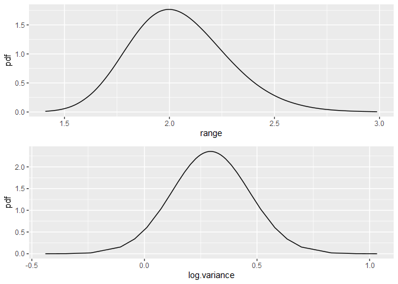

```r
spde.range <- spde.posterior(fit2, "mySmooth", what = "range")
spde.logvar <- spde.posterior(fit2, "mySmooth", what = "log.variance")
range.plot <- plot(spde.range)
var.plot <- plot(spde.logvar)
multiplot(range.plot, var.plot)
```

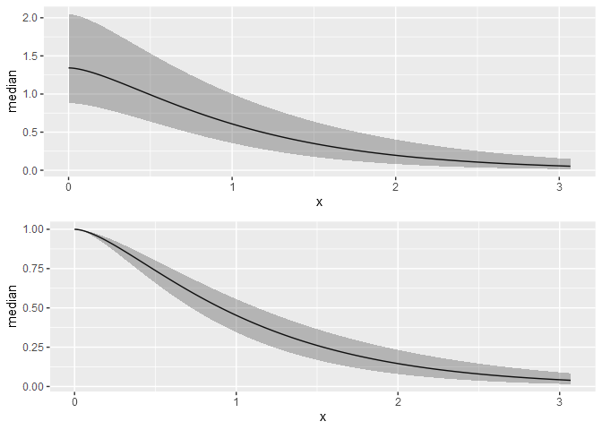

```r
corplot <- plot(spde.posterior(fit2, "mySmooth", what = "matern.correlation"))
covplot <- plot(spde.posterior(fit2, "mySmooth", what = "matern.covariance"))
multiplot(covplot, corplot)
```

## Continuous covariates

Now lets try a model with elevation as a (continuous) explanatory variable. (First centre elevations for more stable fitting.)

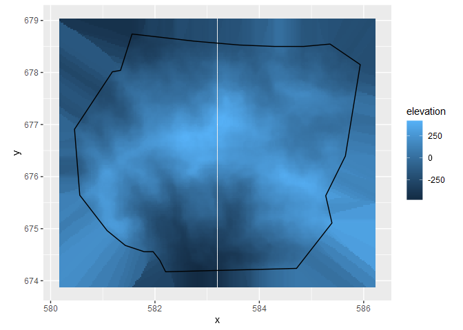

```r
elev <- gcov$elevation
elev$elevation <- elev$elevation - mean(elev$elevation, na.rm = TRUE)
ggplot() +
  gg(elev) +
  gg(boundary, alpha = 0) +
  coord_fixed()
```

The elevation variable here is of class ‘SpatialGridDataFrame’, that can be handled in the same way as the vegetation covariate. However, since in some cases data may be stored differently, and other methods are needed to access the stored values. In such cases, we can define a function that knows how to evaluate the covariate at arbitrary points in the survey region, and call that function in the component definition. In this case, we can use a powerful method from the ‘sp’ package to do this. We use this to create the needed function.

```r
f.elev <- function(x, y) {
  # turn coordinates into SpatialPoints object:
  # with the appropriate coordinate reference system (CRS)
  spp <- SpatialPoints(data.frame(x = x, y = y), proj4string = fm_sp_get_crs(elev))
  proj4string(spp) <- fm_sp_get_crs(elev)
  # Extract elevation values at spp coords, from our elev SpatialGridDataFrame
  v <- over(spp, elev)
  if (any(is.na(v$elevation))) {
    v$elevation <- inlabru:::bru_fill_missing(elev, spp, v$elevation)
  }
  return(v$elevation)
}
```

For brevity we are not going to consider models with elevation only, with elevation and a SPDE, and with SPDE only. We will just fit one with elevation and SPDE. We create our model to pass to lgcp thus:

```r
matern <- inla.spde2.pcmatern(mesh,
  prior.sigma = c(0.1, 0.01),
  prior.range = c(5, 0.01)
)
ecomp <- coordinates ~ elev(f.elev(x, y), model = "linear") +
  mySmooth(coordinates, model = matern) + Intercept(1)
```

Note how the elevation effect is defined. When we used the `Spatial` grid object directly we specified it like

```r
vegetation(gcov$vegetation, model = "factor_full")
```

whereas with the function method we specify the covariate like this:

```r
elev(f.elev(x, y), model = "linear")
```

We also now include an intercept term.

The model is fitted in the usual way:

```r
efit <- lgcp(ecomp, nests, samplers = boundary, domain = list(coordinates = mesh))
```

!JL!

So, my understanding is that the fitting always needs a function, but INLA[bru] has a whitelist of object types that it can automatically grab the function out of. I assume this means the two cases are identical in terms of speed (assuming the functions take about the same time).

!JL!

Summary and model selection

```r
summary(efit)
```

```
#> inlabru version: 2.5.2
#> INLA version: 22.05.07
#> Components:
#>   elev: Model types main='linear', group='exchangeable', replicate='iid'
#>   mySmooth: Model types main='spde', group='exchangeable', replicate='iid'
#>   Intercept: Model types main='linear', group='exchangeable', replicate='iid'
#> Likelihoods:
#>   Family: 'cp'
#>     Data class: 'SpatialPointsDataFrame'
#>     Predictor: coordinates ~ .
#> Time used:
#>     Pre = 2.65, Running = 22, Post = 1.5, Total = 26.1
#> Fixed effects:
#>            mean    sd 0.025quant 0.5quant 0.975quant mode kld
#> elev      0.003 0.001      0.002    0.003      0.005   NA   0
#> Intercept 1.061 0.569     -0.090    1.071      2.158   NA   0
#>
#> Random effects:
#>   Name     Model
#>     mySmooth SPDE2 model
#>
#> Model hyperparameters:
#>                    mean   sd 0.025quant 0.5quant 0.975quant mode
#> Range for mySmooth 2.09 0.25      1.649     2.08       2.63   NA
#> Stdev for mySmooth 1.04 0.09      0.872     1.04       1.23   NA
#>
#> Deviance Information Criterion (DIC) ...............: 502.43
#> Deviance Information Criterion (DIC, saturated) ....: -16274.62
#> Effective number of parameters .....................: -843.13
#>
#> Watanabe-Akaike information criterion (WAIC) ...: 1576.01
#> Effective number of parameters .................: 133.45
#>
#> Marginal log-Likelihood:  -1263.34
#>  is computed
#> Posterior summaries for the linear predictor and the fitted values are computed
#> (Posterior marginals needs also 'control.compute=list(return.marginals.predictor=TRUE)')
```

```r
deltaIC(fit1, fit2, fit3, efit)
```

```
#>   Model       DIC Delta.DIC
#> 1  fit1 -692.9239     0.000
#> 2  efit  502.4261  1195.350
#> 3  fit3  509.9149  1202.839
#> 4  fit2  598.2010  1291.125
```

Predict and plot the density

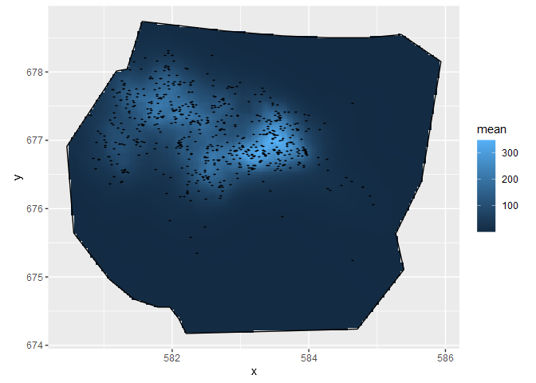

```r
e.int <- predict(efit, pixels(mesh, mask = boundary), ~ exp(mySmooth + elev + Intercept))
ggplot() +
  gg(e.int) +
  gg(boundary, alpha = 0) +
  gg(nests, shape = "+") +
  coord_equal()
```

Now look at the elevation and SPDE effects in space. Leave out the Intercept because it swamps the spatial effects of elevation and the SPDE in the plots and we are interested in comparing the effects of elevation and the SPDE.

First we need to predict on the linear predictor scale.

```r
e.lp <- predict(
  efit, pixels(mesh, mask = boundary),
  ~ list(
    smooth_elev = mySmooth + elev,
    elev = elev,
    smooth = mySmooth
  )
)
```

The code below, which is very similar to that used for the vegetation factor variable, produces the plots we want.

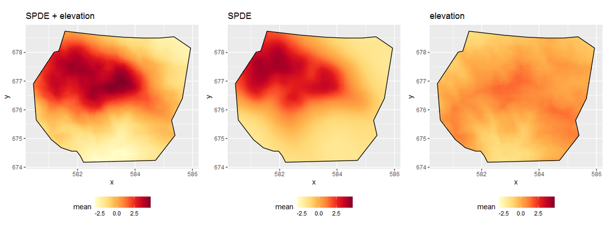

```r
lprange <- range(e.lp$smooth_elev$mean, e.lp$elev$mean, e.lp$smooth$mean)
library(RColorBrewer)
csc <- scale_fill_gradientn(colours = brewer.pal(9, "YlOrRd"), limits = lprange)
plot.e.lp <- ggplot() +
  gg(e.lp$smooth_elev, mask = boundary) +
  csc +
  theme(legend.position = "bottom") +
  gg(boundary, alpha = 0) +
  ggtitle("SPDE + elevation") +
  coord_equal()
plot.e.lp.spde <- ggplot() +
  gg(e.lp$smooth, mask = boundary) +
  csc +
  theme(legend.position = "bottom") +
  gg(boundary, alpha = 0) +
  ggtitle("SPDE") +
  coord_equal()
plot.e.lp.elev <- ggplot() +
  gg(e.lp$elev, mask = boundary) +
  csc +
  theme(legend.position = "bottom") +
  gg(boundary, alpha = 0) +
  ggtitle("elevation") +
  coord_equal()
multiplot(plot.e.lp,
  plot.e.lp.spde,
  plot.e.lp.elev,
  cols = 3
)
```

You might also want to look at the posteriors of the fixed effects and of the SPDE. Adapt the code used for the vegetation factor to do this.

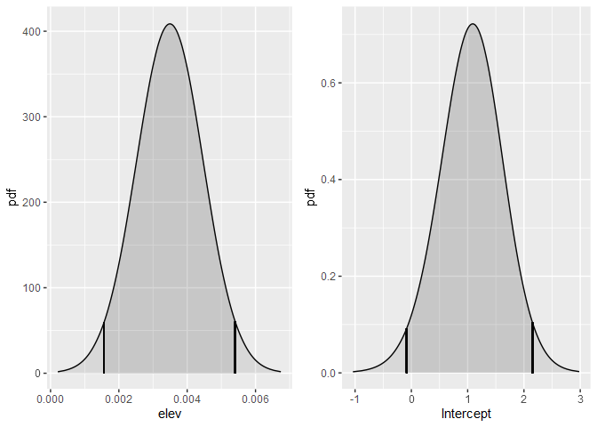

```r
flist <- vector("list", NROW(efit$summary.fixed))
for (i in seq_along(flist)) {
  flist[[i]] <- plot(efit, rownames(efit$summary.fixed)[i])
}
multiplot(plotlist = flist, cols = 2)
```

Plot the SPDE parameter posteriors and the Matern correlation and covariance functions for this model.

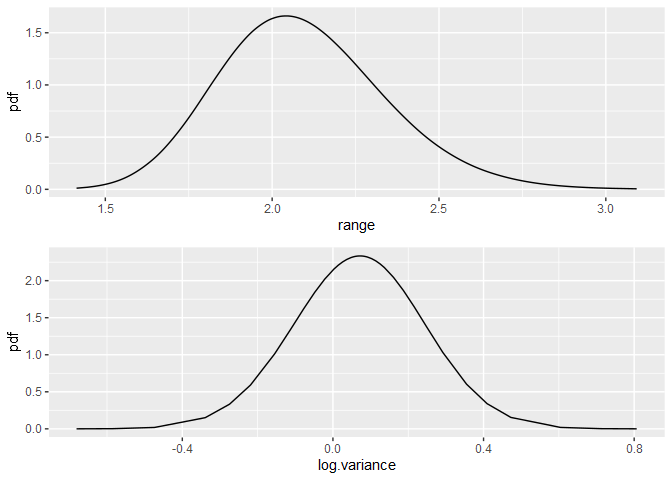

```r
spde.range <- spde.posterior(efit, "mySmooth", what = "range")
spde.logvar <- spde.posterior(efit, "mySmooth", what = "log.variance")
range.plot <- plot(spde.range)
var.plot <- plot(spde.logvar)
multiplot(range.plot, var.plot)
```

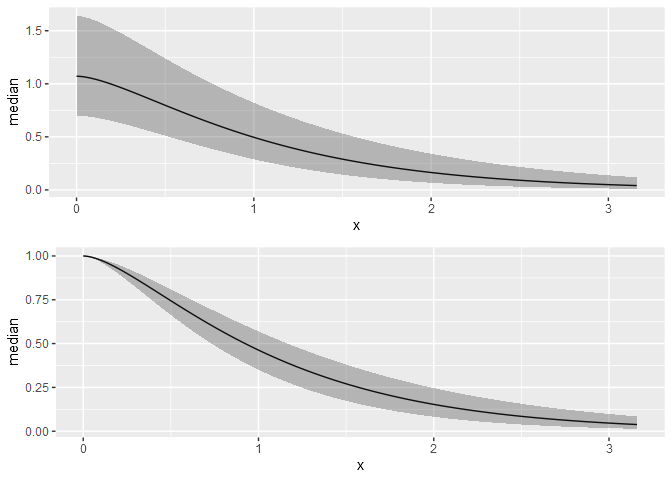

```r
corplot <- plot(spde.posterior(efit, "mySmooth", what = "matern.correlation"))
covplot <- plot(spde.posterior(efit, "mySmooth", what = "matern.covariance"))
multiplot(covplot, corplot)
```

Also estimate abundance. The `data.frame` in the second call leads to inclusion of `N` in the prediction object, for easier plotting.

```r
Lambda <- predict(
  efit, ipoints(boundary, mesh),
  ~ sum(weight * exp(mySmooth + elev + Intercept))
)
Lambda
```

```
#>       mean      sd   q0.025   median  q0.975     smin     smax         cv
#> 1 672.0761 27.0217 615.2542 671.3601 721.412 608.8957 726.1566 0.04020631
#>        var
#> 1 730.1723
```

```r
Nest.e <- predict(
  efit,
  ipoints(boundary, mesh),
  ~ data.frame(
    N = 200:1000,
    density = dpois(200:1000,
      lambda = sum(weight * exp(mySmooth + elev + Intercept))
    )
  ),
  n.samples = 2000
)
```

Plot in the same way as in previous practicals

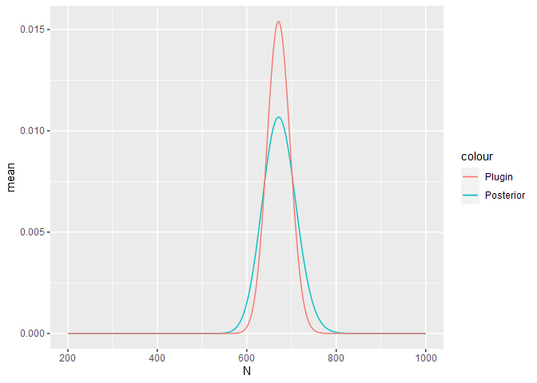

```r
Nest.e$plugin_estimate <- dpois(Nest.e$N, lambda = Lambda$median)
ggplot(data = Nest.e) +
  geom_line(aes(x = N, y = mean, colour = "Posterior")) +
  geom_line(aes(x = N, y = plugin_estimate, colour = "Plugin"))
```

### Non-spatial evaluation of the covariate effect

The previous examples of posterior prediction focused on spatial prediction. From `inlabru` version 2.2.8, a feauture is available for overriding the component input value specification from the component definition. Each model component can be evaluated directly, for arbitrary values by functions named by adding the suffix `_eval` to the end of the component name in the predictor expression. Since the elevation effect in this model is linear, the resulting plot isn’t very interesting, but the same method can be applied to non-linear effects as well, and combined into general R expressions:

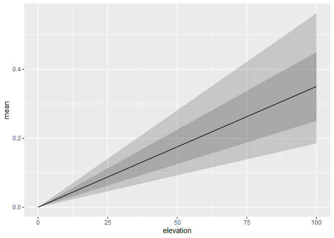

```r
elev.pred <- predict(
  efit,
  data = data.frame(elevation = seq(0, 100, length.out = 1000)),
  formula = ~ elev_eval(elevation)
)
ggplot(elev.pred) +
  geom_line(aes(elevation, mean)) +
  geom_ribbon(aes(elevation,
                  ymin = q0.025,
                  ymax = q0.975),
              alpha = 0.2) +
  geom_ribbon(aes(elevation,
                  ymin = mean - 1 * sd,
                  ymax = mean + 1 * sd),
              alpha = 0.2)
```

## A 1D Example

Try fitting a 1-dimensional model to the point data in the `inlabru` dataset `Poisson2_1D`. This comes with a covariate function called `cov2_1D`. Try to reproduce the plot below (used in lectures) showing the effects of the `Intercept + z` and the `SPDE`. (You may find it helpful to build on the model you fitted in the previous practical, adding the covariate to the model specification.)

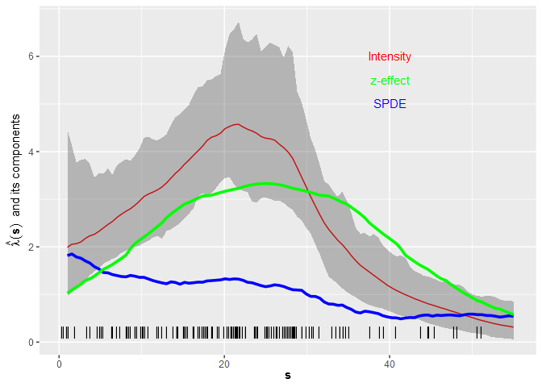

[output not shown]

```r
data(Poisson2_1D)
ss <- seq(0, 55, length = 200)
z <- cov2_1D(ss)
x <- seq(1, 55, length = 100)
mesh <- inla.mesh.1d(x, degree = 1)
comp <- x ~
  beta_z(cov2_1D(x), model = "linear") +
  spde1D(x, model = inla.spde2.matern(mesh)) +
  Intercept(1)
fitcov1D <- lgcp(comp, pts2, domain = list(x = mesh))
pr.df <- data.frame(x = x)
prcov1D <- predict(
  fitcov1D, pr.df,
  ~ list(
    total = exp(beta_z + spde1D + Intercept),
    fx = exp(beta_z + Intercept),
    spde = exp(spde1D)
  )
)
ggplot() +
  gg(prcov1D$total, color = "red") +
  geom_line(aes(x = prcov1D$spde$x, y = prcov1D$spde$median), col = "blue", lwd = 1.25) +
  geom_line(aes(x = prcov1D$fx$x, y = prcov1D$fx$median), col = "green", lwd = 1.25) +
  geom_point(data = pts2, aes(x = x), y = 0.2, shape = "|", cex = 4) +
  xlab(expression(bold(s))) +
  ylab(expression(hat(lambda)(bold(s)) ~ ~"and its components")) +
  annotate(geom = "text", x = 40, y = 6, label = "Intensity", color = "red") +
  annotate(geom = "text", x = 40, y = 5.5, label = "z-effect", color = "green") +
  annotate(geom = "text", x = 40, y = 5, label = "SPDE", color = "blue")
```